# Stroke Prediction

Kiran

2022-12-01

```r
library(dplyr)
#library(DMwR)
library(data.table)
library(ggplot2)
#library(tidyverse)
library(gmodels)
library(caret)
library(class)
library(randomForest)
library(ROCR)
library(gbm)
library(e1071)
library(keras)
library(tfruns)
```

```r
stock_dataset=read.csv('C:/Users/csc/Desktop/New folder/healthcare-dataset-stroke-data.csv',sep=",", header=TRUE, na.strings = c("", "N/A"))
str(stock_dataset)
```

```
'data.frame':   5110 obs. of  12 variables:
 $ id               : int  9046 51676 31112 60182 1665 56669 53882 10434 27419 60491 ...
 $ gender           : chr  "Male" "Female" "Male" "Female" ...
 $ age              : num  67 61 80 49 79 81 74 69 59 78 ...
 $ hypertension     : int  0 0 0 0 1 0 1 0 0 0 ...
 $ heart_disease    : int  1 0 1 0 0 0 1 0 0 0 ...
 $ ever_married     : chr  "Yes" "Yes" "Yes" "Yes" ...
 $ work_type        : chr  "Private" "Self-employed" "Private" "Private" ...
 $ Residence_type   : chr  "Urban" "Rural" "Rural" "Urban" ...
 $ avg_glucose_level: num  229 202 106 171 174 ...
 $ bmi              : num  36.6 NA 32.5 34.4 24 29 27.4 22.8 NA 24.2 ...
 $ smoking_status   : chr  "formerly smoked" "never smoked" "never smoked" "smokes" ...
 $ stroke           : int  1 1 1 1 1 1 1 1 1 1 ...
```

```r
colSums(is.na(stock_dataset))
```

```
               id            gender               age      hypertension     heart_disease      ever_married         work_type    Residence_type
                0                 0                 0                 0                 0                 0                 0                 0
avg_glucose_level               bmi    smoking_status            stroke
                0               201                 0                 0
```

```r
summary(stock_dataset)
```

```
       id           gender               age         hypertension     heart_disease     ever_married        work_type
 Min.   :   67   Length:5110        Min.   : 0.08   Min.   :0.00000   Min.   :0.00000   Length:5110        Length:5110
 1st Qu.:17741   Class :character   1st Qu.:25.00   1st Qu.:0.00000   1st Qu.:0.00000   Class :character   Class :character
 Median :36932   Mode  :character   Median :45.00   Median :0.00000   Median :0.00000   Mode  :character   Mode  :character
 Mean   :36518                      Mean   :43.23   Mean   :0.09746   Mean   :0.05401
 3rd Qu.:54682                      3rd Qu.:61.00   3rd Qu.:0.00000   3rd Qu.:0.00000
 Max.   :72940                      Max.   :82.00   Max.   :1.00000   Max.   :1.00000

 Residence_type     avg_glucose_level      bmi        smoking_status         stroke
 Length:5110        Min.   : 55.12    Min.   :10.30   Length:5110        Min.   :0.00000
 Class :character   1st Qu.: 77.25    1st Qu.:23.50   Class :character   1st Qu.:0.00000
 Mode  :character   Median : 91.89    Median :28.10   Mode  :character   Median :0.00000
                    Mean   :106.15    Mean   :28.89                      Mean   :0.04873
                    3rd Qu.:114.09    3rd Qu.:33.10                      3rd Qu.:0.00000
                    Max.   :271.74    Max.   :97.60                      Max.   :1.00000
                                      NA's   :201
```

```r
# stock_dataset= na.omit(stock_dataset)


Mode <- function (x, na.rm) {
    xtab <- table(x)
    xmode <- names(which(xtab == max(xtab)))
    if (length(xmode) > 1) xmode <- ">1 mode"
    return(xmode)
}

for (var in 1:ncol(stock_dataset)) {
    if (class(stock_dataset[,var])=="numeric") {
        stock_dataset[is.na(stock_dataset[,var]),var] <- mean(stock_dataset[,var], na.rm = TRUE)
    } else if (class(stock_dataset[,var]) %in% c("character", "factor")) {
        stock_dataset[is.na(stock_dataset[,var]),var] <- Mode(stock_dataset[,var], na.rm = TRUE)
    }
}



 #stock_dataset[is.na(stock_dataset[,var]),var] <- Mode(stock_dataset[,var], na.rm = TRUE)

 colSums(is.na(stock_dataset))
```

```
               id            gender               age      hypertension     heart_disease      ever_married         work_type    Residence_type
                0                 0                 0                 0                 0                 0                 0                 0
avg_glucose_level               bmi    smoking_status            stroke
                0                 0                 0                 0
```

```r
colSums(is.na(stock_dataset))
```

```
               id            gender               age      hypertension     heart_disease      ever_married         work_type    Residence_type
                0                 0                 0                 0                 0                 0                 0                 0
avg_glucose_level               bmi    smoking_status            stroke
                0                 0                 0                 0
```

```r
str(stock_dataset)
```

```
'data.frame':   5110 obs. of  12 variables:
 $ id               : int  9046 51676 31112 60182 1665 56669 53882 10434 27419 60491 ...
 $ gender           : chr  "Male" "Female" "Male" "Female" ...
 $ age              : num  67 61 80 49 79 81 74 69 59 78 ...
 $ hypertension     : int  0 0 0 0 1 0 1 0 0 0 ...
 $ heart_disease    : int  1 0 1 0 0 0 1 0 0 0 ...
 $ ever_married     : chr  "Yes" "Yes" "Yes" "Yes" ...
 $ work_type        : chr  "Private" "Self-employed" "Private" "Private" ...
 $ Residence_type   : chr  "Urban" "Rural" "Rural" "Urban" ...
 $ avg_glucose_level: num  229 202 106 171 174 ...
 $ bmi              : num  36.6 28.9 32.5 34.4 24 ...
 $ smoking_status   : chr  "formerly smoked" "never smoked" "never smoked" "smokes" ...
 $ stroke           : int  1 1 1 1 1 1 1 1 1 1 ...
```

```r
colMeans(is.na(stock_dataset))
```

```
               id            gender               age      hypertension     heart_disease      ever_married         work_type    Residence_type
                0                 0                 0                 0                 0                 0                 0                 0
avg_glucose_level               bmi    smoking_status            stroke
                0                 0                 0                 0
```

```r
stock_dataset=stock_dataset[,-1]

stock_dataset = as.data.frame(unclass(stock_dataset), stringsAsFactors = TRUE)

stock_dataset$stroke[stock_dataset$stroke=="1"] <- "Yes"
stock_dataset$stroke[stock_dataset$stroke=="0"] <- "No"

stock_dataset$stroke = as.factor(stock_dataset$stroke)
# stock_dataset$gender = as.factor(stock_dataset$gender)
# stock_dataset$hypertension = as.factor(stock_dataset$hypertension)
# stock_dataset$heart_disease = as.factor(stock_dataset$heart_disease)
# stock_dataset$ever_married = as.factor(stock_dataset$ever_married)
# stock_dataset$work_type = as.factor(stock_dataset$work_type)
# stock_dataset$Residence_type = as.factor(stock_dataset$Residence_type)
# stock_dataset$smoking_status = as.factor(stock_dataset$smoking_status)

str(stock_dataset)
```

```
'data.frame':   5110 obs. of  11 variables:
 $ gender           : Factor w/ 3 levels "Female","Male",..: 2 1 2 1 1 2 2 1 1 1 ...
 $ age              : num  67 61 80 49 79 81 74 69 59 78 ...
 $ hypertension     : int  0 0 0 0 1 0 1 0 0 0 ...
 $ heart_disease    : int  1 0 1 0 0 0 1 0 0 0 ...
 $ ever_married     : Factor w/ 2 levels "No","Yes": 2 2 2 2 2 2 2 1 2 2 ...
 $ work_type        : Factor w/ 5 levels "children","Govt_job",..: 4 5 4 4 5 4 4 4 4 4 ...
 $ Residence_type   : Factor w/ 2 levels "Rural","Urban": 2 1 1 2 1 2 1 2 1 2 ...
 $ avg_glucose_level: num  229 202 106 171 174 ...
 $ bmi              : num  36.6 28.9 32.5 34.4 24 ...
 $ smoking_status   : Factor w/ 4 levels "formerly smoked",..: 1 2 2 3 2 1 2 2 4 4 ...
 $ stroke           : Factor w/ 2 levels "No","Yes": 2 2 2 2 2 2 2 2 2 2 ...
```

```r
sum(is.na(stock_dataset))
```

```
[1] 0
```

```r
df_1 =  stock_dataset[stock_dataset$stroke == "No",]
df_2 =  stock_dataset[stock_dataset$stroke== "Yes",]
```

```r
#install.packages("ggplot2")

#library(ggcorrplot)
# model.matrix(~0+., data=stock_dataset) %>%
#    cor(use="pairwise.complete.obs") %>%
#    ggcorrplot(show.diag = F, type="lower", lab=TRUE, lab_size=2)
```

[figure not shown]

```r
#Gender


library(gridExtra)
#arrangeGrob(f1.1, f1.2, f1.3)



#ggplot(stock_dataset, aes(stroke, ..count..)) + geom_bar(aes(fill = gender), position = "dodge")

graph1= ggplot(data=stock_dataset, aes(x=gender, y=factor(stroke), fill=gender)) +geom_bar(stat="identity") + ggtitle("Stroke = 1") + theme(plot.title=element_text(size=20,hjust = 0.5))
graph2 = ggplot(data=stock_dataset, aes(x=gender, y=factor(stroke), fill=gender)) +geom_bar(stat="identity") + ggtitle("Stroke = 0") + theme(plot.title=element_text(size=20,hjust = 0.5))
options(repr.plot.width=15, repr.plot.height=8)
grid.arrange(graph1, graph2, ncol = 2, nrow = 1)
```

```r
test <- chisq.test(table(stock_dataset$gender, stock_dataset$stroke))
test
```

```
    Pearson's Chi-squared test

data:  table(stock_dataset$gender, stock_dataset$stroke)
X-squared = 0.47259, df = 2, p-value = 0.7895
```

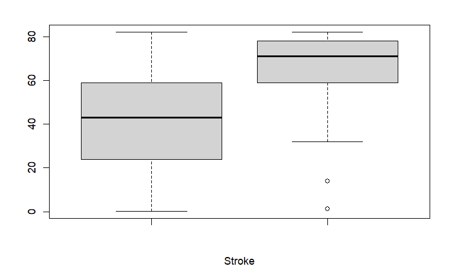

```r
#Age

boxplot(df_1$age,df_2$age,xlab="Stroke")
```

```r
t.test(stock_dataset$age~stock_dataset$stroke)
```

```
    Welch Two Sample t-test

data:  stock_dataset$age by stock_dataset$stroke
t = -29.686, df = 331.65, p-value < 2.2e-16
alternative hypothesis: true difference in means between group No and group Yes is not equal to 0
95 percent confidence interval:
 -27.4634 -24.0499
sample estimates:
 mean in group No mean in group Yes
         41.97154          67.72819
```

Here output of t-test shows that p-value is less than significance level and we can reject null hypothesis and accept alternate hpothesis which says that difference in age means for two groups with (no stroke)0 and (stroke)1 is not equal to 0.

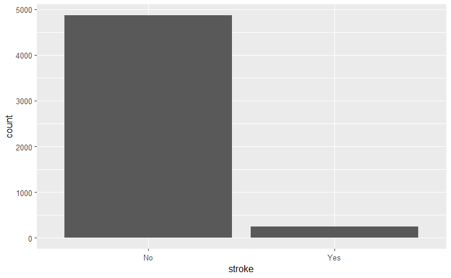

```r
#HyperTension


ggplot(stock_dataset, aes(stroke, ..count..)) + geom_bar(aes(fill = hypertension), position = "dodge")
```

```r
#boxplot(df_1$hypertension,df_2$hypertension, xlab="Stroke")
t.test(stock_dataset$hypertension~stock_dataset$stroke)
```

```
    Welch Two Sample t-test

data:  stock_dataset$hypertension by stock_dataset$stroke
t = -6.2209, df = 258.63, p-value = 1.978e-09
alternative hypothesis: true difference in means between group No and group Yes is not equal to 0
95 percent confidence interval:
 -0.2319615 -0.1204178
sample estimates:
 mean in group No mean in group Yes
        0.0888706         0.2650602
```

```r
#CrossTable(stock_dataset$stroke, stock_dataset$hypertension,chisq=TRUE)
```

You obtained a p-value of 1.978e-09, lower than the threshold of 0.05. You can reject the null (H0) hypothesis.true difference in means between group 0 and group 1 is not equal to 0

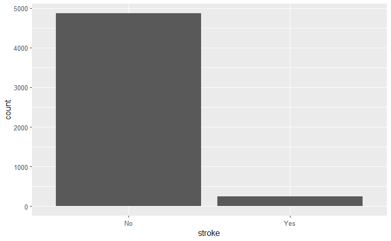

```r
#Heart Disease

ggplot(stock_dataset, aes(stroke, ..count..)) + geom_bar(aes(fill = heart_disease), position = "dodge")
```

```r
#boxplot(df_1$heart_disease,df_2$heart_disease, xlab="Stroke")
t.test(stock_dataset$heart_disease~stock_dataset$stroke)
```

```
    Welch Two Sample t-test

data:  stock_dataset$heart_disease by stock_dataset$stroke
t = -5.6582, df = 255.47, p-value = 4.095e-08
alternative hypothesis: true difference in means between group No and group Yes is not equal to 0
95 percent confidence interval:
 -0.19094392 -0.09234682
sample estimates:
 mean in group No mean in group Yes
       0.04710965        0.18875502
```

```r
#CrossTable(stock_dataset$stroke, stock_dataset$heart_disease,chisq=TRUE)
```

we obtained a p-value of 4.095e-08, lower than the threshold of 0.05. You can reject the null (H0) hypothesis.true difference in means between group 0 and group 1 is not equal to 0

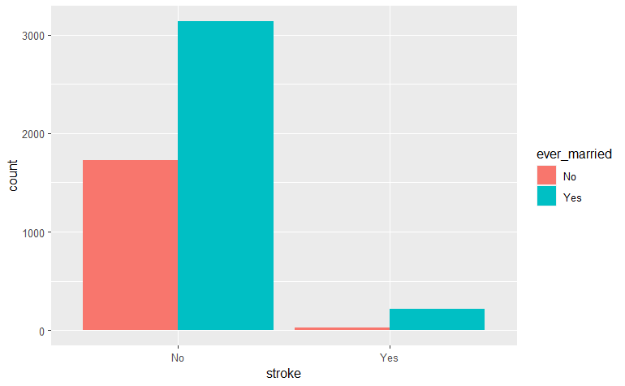

```r
#Ever Married




ggplot(stock_dataset, aes(stroke, ..count..)) + geom_bar(aes(fill = ever_married), position = "dodge")
```

```r
test <- chisq.test(table(stock_dataset$ever_married, stock_dataset$stroke))
test
```

```
    Pearson's Chi-squared test with Yates' continuity correction

data:  table(stock_dataset$ever_married, stock_dataset$stroke)
X-squared = 58.924, df = 1, p-value = 1.639e-14
```

```r
#CrossTable(stock_dataset$stroke, stock_dataset$heart_disease,chisq=TRUE)
```

We have a chi-squared value of 58.924. Since we get the p-Value is 1.639e-14 less than the significance level of 0.05, we can reject the null hypothesis and conclude that the two variables are in fact dependent.

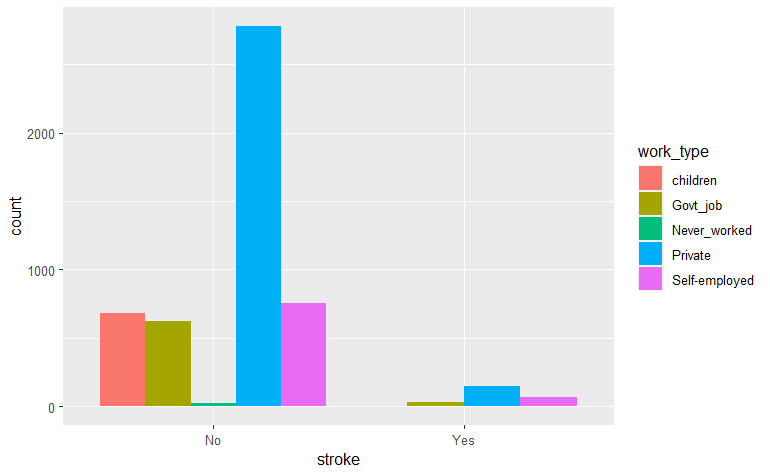

```r
#Work Type

ggplot(stock_dataset, aes(stroke, ..count..)) + geom_bar(aes(fill = work_type), position = "dodge")
```

```r
test <- chisq.test(table(stock_dataset$work_type, stock_dataset$stroke))
test
```

```
    Pearson's Chi-squared test

data:  table(stock_dataset$work_type, stock_dataset$stroke)
X-squared = 49.164, df = 4, p-value = 5.398e-10
```

```r
#CrossTable(stock_dataset$stroke, stock_dataset$ever_married,chisq=TRUE)
```

We have a chi-squared value of 49.164. Since we get the p-Value 5.398e-10 is less than the significance level of 0.05, we can reject the null hypothesis and conclude that the two variables are in fact dependent.

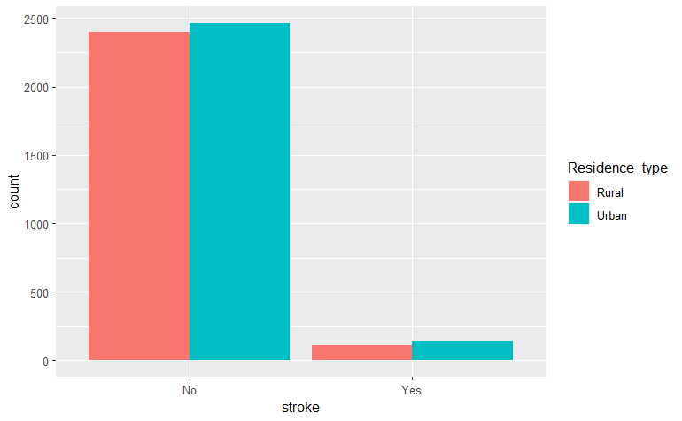

```r
#Residence Type

ggplot(stock_dataset, aes(stroke, ..count..)) + geom_bar(aes(fill = Residence_type), position = "dodge")
```

```r
test <- chisq.test(table(stock_dataset$Residence_type, stock_dataset$stroke))
test
```

```
    Pearson's Chi-squared test with Yates' continuity correction

data:  table(stock_dataset$Residence_type, stock_dataset$stroke)
X-squared = 1.0816, df = 1, p-value = 0.2983
```

```r
#CrossTable(stock_dataset$stroke, stock_dataset$work_type,chisq=TRUE)
```

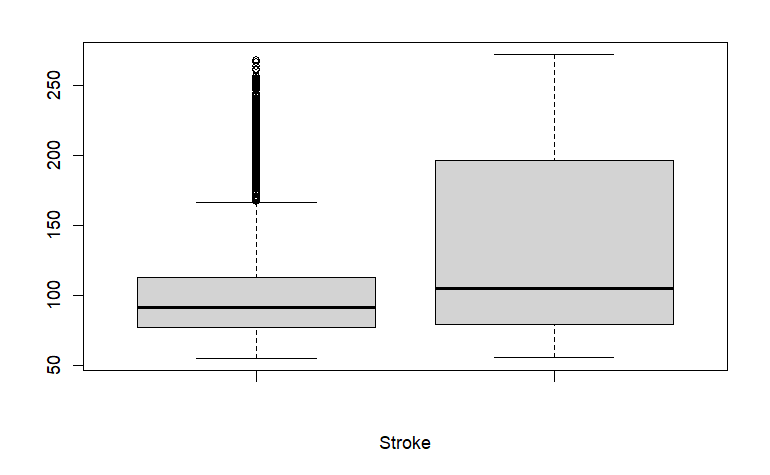

```r
boxplot(df_1$avg_glucose_level,df_2$avg_glucose_level, xlab="Stroke")
```

```r
t.test(stock_dataset$avg_glucose_level~stock_dataset$stroke)
```

```
    Welch Two Sample t-test

data:  stock_dataset$avg_glucose_level by stock_dataset$stroke
t = -6.9824, df = 260.89, p-value = 2.401e-11
alternative hypothesis: true difference in means between group No and group Yes is not equal to 0
95 percent confidence interval:
 -35.57474 -19.92371
sample estimates:
 mean in group No mean in group Yes
         104.7955          132.5447
```

we obtained a p-value of 2.401e-11, lower than the threshold of 0.05. You can reject the null (H0) hypothesis.true difference in means between group 0 and group 1 is not equal to 0

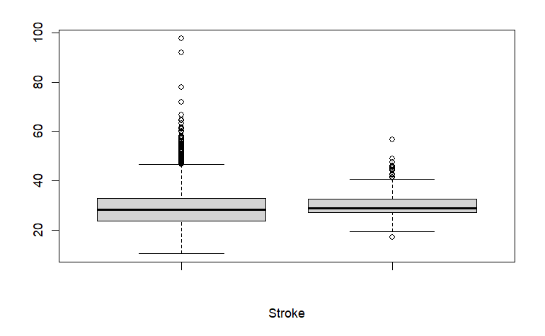

```r
boxplot(df_1$bmi,df_2$bmi, xlab="Stroke")
```

```r
t.test(stock_dataset$bmi~stock_dataset$stroke)
```

```
    Welch Two Sample t-test

data:  stock_dataset$bmi by stock_dataset$stroke
t = -3.6104, df = 295.21, p-value = 0.0003591
alternative hypothesis: true difference in means between group No and group Yes is not equal to 0
95 percent confidence interval:
 -2.1513954 -0.6334067
sample estimates:
 mean in group No mean in group Yes
         28.82539          30.21779
```

we obtained a p-value of 0.0003591, lower than the threshold of 0.05. You can reject the null (H0) hypothesis.true difference in means between group 0 and group 1 is not equal to 0

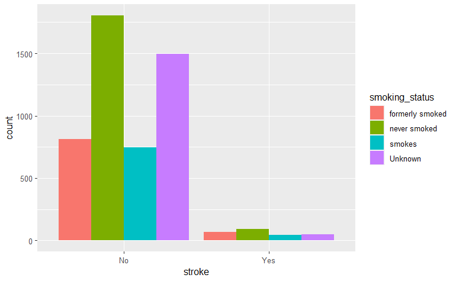

```r
ggplot(stock_dataset, aes(stroke, ..count..)) + geom_bar(aes(fill = smoking_status), position = "dodge")
```

```r
test <- chisq.test(table(stock_dataset$smoking_status, stock_dataset$stroke))
test
```

```
    Pearson's Chi-squared test

data:  table(stock_dataset$smoking_status, stock_dataset$stroke)
X-squared = 29.147, df = 3, p-value = 2.085e-06
```

```r
#CrossTable(stock_dataset$stroke, stock_dataset$Residence_type,chisq=TRUE)
```

```r
summary(stock_dataset)
```

```
    gender          age         hypertension     heart_disease     ever_married         work_type    Residence_type avg_glucose_level
 Female:2994   Min.   : 0.08   Min.   :0.00000   Min.   :0.00000   No :1757     children     : 687   Rural:2514     Min.   : 55.12
 Male  :2115   1st Qu.:25.00   1st Qu.:0.00000   1st Qu.:0.00000   Yes:3353     Govt_job     : 657   Urban:2596     1st Qu.: 77.25
 Other :   1   Median :45.00   Median :0.00000   Median :0.00000                Never_worked :  22                  Median : 91.89
               Mean   :43.23   Mean   :0.09746   Mean   :0.05401                Private      :2925                  Mean   :106.15
               3rd Qu.:61.00   3rd Qu.:0.00000   3rd Qu.:0.00000                Self-employed: 819                  3rd Qu.:114.09
               Max.   :82.00   Max.   :1.00000   Max.   :1.00000                                                    Max.   :271.74
      bmi                smoking_status stroke
 Min.   :10.30   formerly smoked: 885   No :4861
 1st Qu.:23.80   never smoked   :1892   Yes: 249
 Median :28.40   smokes         : 789
 Mean   :28.89   Unknown        :1544
 3rd Qu.:32.80
 Max.   :97.60
```

```r
str(stock_dataset)
```

```
'data.frame':   5110 obs. of  11 variables:
 $ gender           : Factor w/ 3 levels "Female","Male",..: 2 1 2 1 1 2 2 1 1 1 ...
 $ age              : num  67 61 80 49 79 81 74 69 59 78 ...
 $ hypertension     : int  0 0 0 0 1 0 1 0 0 0 ...
 $ heart_disease    : int  1 0 1 0 0 0 1 0 0 0 ...
 $ ever_married     : Factor w/ 2 levels "No","Yes": 2 2 2 2 2 2 2 1 2 2 ...
 $ work_type        : Factor w/ 5 levels "children","Govt_job",..: 4 5 4 4 5 4 4 4 4 4 ...
 $ Residence_type   : Factor w/ 2 levels "Rural","Urban": 2 1 1 2 1 2 1 2 1 2 ...
 $ avg_glucose_level: num  229 202 106 171 174 ...
 $ bmi              : num  36.6 28.9 32.5 34.4 24 ...
 $ smoking_status   : Factor w/ 4 levels "formerly smoked",..: 1 2 2 3 2 1 2 2 4 4 ...
 $ stroke           : Factor w/ 2 levels "No","Yes": 2 2 2 2 2 2 2 2 2 2 ...
```

*Data Preparation*

```r
# library(ggplot2)
# library(knitr)
# #install.packages("smotefamily")
# install.packages("unbalanced")
# library(unbalanced)
#library(unbalanced)
# suppressMessages(library(dplyr))
# suppressMessages(library(unbalanced))
```

```r
#install.packages("https://cran.r-project.org/src/contrib/Archive/DMwR/DMwR_0.4.1.tar.gz", repos=NULL, type="source")
```

```r
set.seed(2)
rows=sample(nrow(stock_dataset))
stock_dataset=stock_dataset[rows, ]
```

```r
unique(stock_dataset$stroke)
```

```
[1] No  Yes
Levels: No Yes
```

```r
unique(stock_dataset$gender)
```

```
[1] Male   Female Other
Levels: Female Male Other
```

```r
sum(is.na(stock_dataset))
```

```
[1] 0
```

```r
#
# sm = table(stock_dataset$stroke)
# zero = sm[[1]]
# one = sm[[2]]
# total_rows = nrow(stock_dataset)
# (zero/total_rows)*100
# (one/total_rows)*100
```

```r
#install.packages("devtools", force = TRUE)
#library(devtools)
#install_github("cran/DMwR", force = TRUE)
#library(DMwR)


# install.packages("bitops",repos="https://cran.r-project.org/bin/windows/contrib/3.3/bitops_1.0-6.zip",dependencies=TRUE,type="source")
#  install.packages('abind')
#  install.packages('zoo')
#  install.packages('xts')
#  install.packages('quantmod')
#  install.packages('ROCR')
# install.packages("DMwR")
# library(DMwR)
#
# install.packages("devtools", force = TRUE)
# library("devtools")
# install_github("cran/DMwR", force = TRUE)
```

```r
# build_github_devtools()
#
# #### Restart R before continuing ####
# install.packages("devtools.zip", repos = NULL)
#
# # Remove the package after installation
# unlink("devtools.zip")
# install_github("haghbinh/DMwR")
```

```r
str(stock_dataset)
```

```
'data.frame':   5110 obs. of  11 variables:
 $ gender           : Factor w/ 3 levels "Female","Male",..: 2 1 1 1 1 1 2 1 1 1 ...
 $ age              : num  18 5 37 71 82 17 71 50 54 55 ...
 $ hypertension     : int  0 0 0 0 0 0 0 0 0 1 ...
 $ heart_disease    : int  0 0 0 1 0 0 0 0 0 0 ...
 $ ever_married     : Factor w/ 2 levels "No","Yes": 1 1 2 2 2 1 2 2 2 2 ...
 $ work_type        : Factor w/ 5 levels "children","Govt_job",..: 4 1 5 5 4 4 4 2 5 4 ...
 $ Residence_type   : Factor w/ 2 levels "Rural","Urban": 1 2 2 1 2 2 2 2 2 1 ...
 $ avg_glucose_level: num  118.9 62 95.1 98.5 82.6 ...
 $ bmi              : num  22.4 16.8 34.1 29.7 17.9 19.5 27.3 31.5 26.9 34.2 ...
 $ smoking_status   : Factor w/ 4 levels "formerly smoked",..: 2 4 2 4 3 1 1 2 2 2 ...
 $ stroke           : Factor w/ 2 levels "No","Yes": 1 1 1 1 1 1 1 1 1 1 ...
```

```r
# stock_dataset$stroke[stock_dataset$stroke=="1"] <- "Yes"
#
# stock_dataset$stroke[stock_dataset$stroke=="0"] <- "No"
```

```r
str(stock_dataset)
```

```
'data.frame':   5110 obs. of  11 variables:
 $ gender           : Factor w/ 3 levels "Female","Male",..: 2 1 1 1 1 1 2 1 1 1 ...
 $ age              : num  18 5 37 71 82 17 71 50 54 55 ...
 $ hypertension     : int  0 0 0 0 0 0 0 0 0 1 ...
 $ heart_disease    : int  0 0 0 1 0 0 0 0 0 0 ...
 $ ever_married     : Factor w/ 2 levels "No","Yes": 1 1 2 2 2 1 2 2 2 2 ...
 $ work_type        : Factor w/ 5 levels "children","Govt_job",..: 4 1 5 5 4 4 4 2 5 4 ...
 $ Residence_type   : Factor w/ 2 levels "Rural","Urban": 1 2 2 1 2 2 2 2 2 1 ...
 $ avg_glucose_level: num  118.9 62 95.1 98.5 82.6 ...
 $ bmi              : num  22.4 16.8 34.1 29.7 17.9 19.5 27.3 31.5 26.9 34.2 ...
 $ smoking_status   : Factor w/ 4 levels "formerly smoked",..: 2 4 2 4 3 1 1 2 2 2 ...
 $ stroke           : Factor w/ 2 levels "No","Yes": 1 1 1 1 1 1 1 1 1 1 ...
```

```r
# library(DMwR)
# library(unbalanced)

#install.packages("bitops")
#install.packages("DMwR")

library("DMwR")
#smoted_data= SMOTE(stroke~., stock_dataset,  perc.over = 100, k=5)
#
# sm = table(stock_dataset$stroke)
# zero = sm[[1]]
# one = sm[[2]]
# total_rows = nrow(stock_dataset)
# (zero/total_rows)*100
# (one/total_rows)*100

# stock_dataset1 <- as.data.frame(unclass(stock_dataset), stringsAsFactors = TRUE)
#
# #stock_dataset1$stroke <- as.factor(stock_dataset1$stroke)
#
# balancednewsData <- SMOTE(stroke ~ ., stock_dataset1, perc.over = 100, k=5)
#
# table(stock_dataset1$stroke)
#
# table(balancednewsData$stroke)

# ctrl=trainControl(method="cv", number=10, classProbs = TRUE, summaryFunction = twoClassSummary,
# sampling="smote")
# knn_balanced_smote<-train(stroke~., data = stroke_train, method = "knn", verbose=FALSE, metric ="ROC", trControl= ctrl)
```

```r
#str(balancednewsData)
```

```r
# balancednewsData[balancednewsData$stroke == "1"] <- "Yes"
# balancednewsData[balancednewsData$stroke == "0"] <- "No"



#d <- balancednewsData
# d$stroke[d$stroke=="1"] <- "Yes"
#
# d$stroke[d$stroke=="0"] <- "No"

#levels(d$stroke) <- list("1" = "Yes", "0" = "No")


#balancednewsData$stroke <- as.factor(balancednewsData$stroke)

#table(d$stroke)
```

```r
library(caret)
stock_dataset$stroke <- as.factor(stock_dataset$stroke)

inTrainf= caret::createDataPartition(stock_dataset$stroke, p=0.80, list= FALSE)
stroke_train = stock_dataset[inTrainf,]
stroke_test = stock_dataset[-inTrainf,]
```

#Decision Tree (Gradient Boosting Machine )

```r
t=table(stroke_train$stroke)
#t=table(stroke_train$stroke)
w_yes=sum(t)/(t["Yes"]*2)
w_no=sum(t)/(t["No"]*2)
w_yes
```

```
    Yes
10.2225
```

```r
w_no
```

```
       No
0.5257136
```

```r
class_weights= ifelse(stroke_train$stroke=="Yes", w_yes, w_no)
str(class_weights)
```

```
 num [1:4089] 0.526 0.526 0.526 0.526 0.526 ...
```

```r
ctrl=trainControl(method="cv", number=10, classProbs = TRUE, summaryFunction =twoClassSummary)
m_weighted_gbm<-train(stroke ~ ., data = stroke_train, method = "gbm",weights=class_weights,verbose=FALSE, metric ="ROC", trControl= ctrl)
```

```r
gbm_predictions_prob=predict(m_weighted_gbm, stroke_test, type="prob")
gbm_predictions= prediction(gbm_predictions_prob$Yes,stroke_test$stroke)
performance(gbm_predictions, measure = "auc")@y.values
```

```
[[1]]
[1] 0.8397686
```

```r
gbm_predicted_labels = predict(m_weighted_gbm, stroke_test)
confusionMatrix(gbm_predicted_labels, stroke_test$stroke, positive="Yes", mode="everything")
```

```
Confusion Matrix and Statistics

          Reference
Prediction  No Yes
       No  689   9
       Yes 283  40

               Accuracy : 0.714
                 95% CI : (0.6852, 0.7416)
    No Information Rate : 0.952
    P-Value [Acc > NIR] : 1

                  Kappa : 0.1437

 Mcnemar's Test P-Value : <2e-16

            Sensitivity : 0.81633
            Specificity : 0.70885
         Pos Pred Value : 0.12384
         Neg Pred Value : 0.98711
              Precision : 0.12384
                 Recall : 0.81633
                     F1 : 0.21505
             Prevalence : 0.04799
         Detection Rate : 0.03918
   Detection Prevalence : 0.31636
      Balanced Accuracy : 0.76259

       'Positive' Class : Yes
```